# R Notebook

# Load the required packages

```r
library(lme4)
```

```r
library(ggplot2)
library(dplyr)
```

# Create a Dataset

```r
set.seed(123)
```

# Simulated Data

```r
location<-factor(rep(1:3, each=100))
date<-rep(seq.Date(from = as.Date("2023-01-01"), by="days",length.out = 100), times=3)
temperature<-rnorm(300, mean=25, sd=5)
precipitation<- rpois(300, lambda = 10)
ice_cream_sales<-1000+20*temperature-10*precipitation+rnorm(300, mean = 0, sd=100)
```

#Create the Dataset

```r
ice_cream_data<- data.frame(Location=location, Date=date, Temperature= temperature, Precipitation=precipitation, IceCreamsales=ice_cream_sales)
```

#Check the first few raws of the data set

```r
head(ice_cream_data)
```

|  | Location | Date | Temperature | Precipitation | IceCreamsales |
| --- | --- | --- | --- | --- | --- |
| 1 | 1 | 2023-01-01 | 22.19762 | 7 | 1149.047 |
| 2 | 1 | 2023-01-02 | 23.84911 | 8 | 1400.135 |
| 3 | 1 | 2023-01-03 | 32.79354 | 12 | 1556.427 |
| 4 | 1 | 2023-01-04 | 25.35254 | 12 | 1371.516 |
| 5 | 1 | 2023-01-05 | 25.64644 | 8 | 1489.758 |
| 6 | 1 | 2023-01-06 | 33.57532 | 5 | 1722.574 |

```r
summary(ice_cream_data)
```

```
##  Location      Date             Temperature    Precipitation   IceCreamsales
##  1:100    Min.   :2023-01-01   Min.   :13.45   Min.   : 2.00   Min.   : 963
##  2:100    1st Qu.:2023-01-25   1st Qu.:22.12   1st Qu.: 8.00   1st Qu.:1305
##  3:100    Median :2023-02-19   Median :24.78   Median :10.00   Median :1408
##           Mean   :2023-02-19   Mean   :25.17   Mean   : 9.99   Mean   :1409
##           3rd Qu.:2023-03-16   3rd Qu.:28.16   3rd Qu.:12.00   3rd Qu.:1494
##           Max.   :2023-04-10   Max.   :41.21   Max.   :20.00   Max.   :1868
```

#convert location to a factor:Data Preprpcessing

```r
ice_cream_data$Location<-as.factor(ice_cream_data$Location)
```

#Check for missing values

```r
sum(is.na(ice_cream_data))
```

```
## [1] 0
```

#scatter plot of Temprature vs. IceCreamSales:Data Visualization

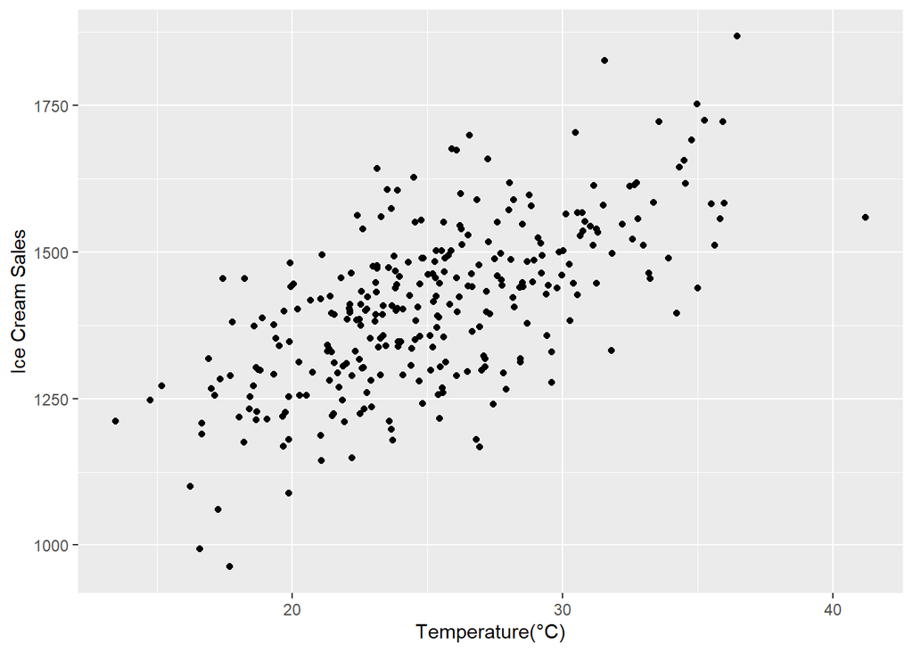

```r
ggplot(ice_cream_data,aes(x=Temperature, y=IceCreamsales))+geom_point()+labs(x="Temperature(°C)", y="Ice Cream Sales")
```

#There is a strong positive relationship between temperature and ice cream sales.

#scatter plot of Precipitation vs. IceCreamSales:Data Visualization

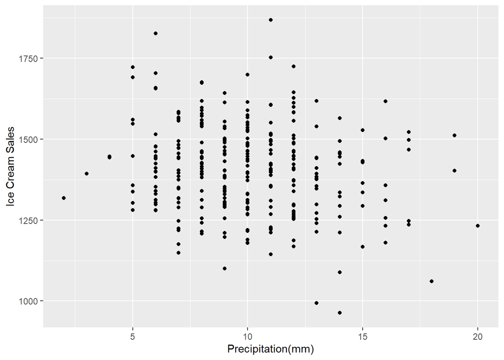

```r
ggplot(ice_cream_data,aes(x=Precipitation, y=IceCreamsales))+geom_point()+labs(x="Precipitation(mm)", y="Ice Cream Sales")
```

#Ice cream sales were high when the precipitation was 5-15 mm.

# Fit the mixed-effects model

```r
ice_cream_model<-lmer(IceCreamsales~Temperature+Precipitation+(1|Location), data = ice_cream_data)
```

```
## boundary (singular) fit: see help('isSingular')
```

# Check Model Summary

```r
summary(ice_cream_model)
```

```
## Linear mixed model fit by REML ['lmerMod']
## Formula: IceCreamsales ~ Temperature + Precipitation + (1 | Location)
##    Data: ice_cream_data
##
## REML criterion at convergence: 3619.1
##
## Scaled residuals:
##      Min       1Q   Median       3Q      Max
## -2.56961 -0.65795  0.02701  0.59883  2.55986
##
## Random effects:
##  Groups   Name        Variance Std.Dev.
##  Location (Intercept)     0      0.0
##  Residual             10636    103.1
## Number of obs: 300, groups:  Location, 3
##
## Fixed effects:
##               Estimate Std. Error t value
## (Intercept)   1008.721     37.197  27.118
## Temperature     19.414      1.262  15.383
## Precipitation   -8.867      1.960  -4.523
##
## Correlation of Fixed Effects:
##             (Intr) Tmprtr
## Temperature -0.835
## Precipitatn -0.496 -0.036
## optimizer (nloptwrap) convergence code: 0 (OK)
## boundary (singular) fit: see help('isSingular')
```

##Interpretation

Formula used for the model is IceCreamsales ~ Temperature + Precipitation + (1 | Location), which means modeling the variation in IceCreamsales with a random intercept for each level of the Location grouping variable.

REML criterion at convergence is 3619.1. Since, this value is large, it does not show the REML criterion is better fit to the data.

Scaled residuals: Min 1Q Median 3Q Max -2.56961 -0.65795 0.02701 0.59883 2.55986

values of scaled residuals lies slightly closer to zero, indicating the moodel fits to data. Most minimun value of the dataset is approximately -2.56961 while the maximum value is 2.55986. Moreover, 25% of residuals are below -0.65795, median is 0.02701 and 75% of residuals are below 0.59883.

The median is close to zero. this indicates that, on average, the models predictions are reasonably close to the observed values.

Random effects: Groups Name Variance Std.Dev. Location (Intercept) 0 0.0  
Residual 10636 103.1  
Number of obs: 300, groups: Location, 3

Randon effects associated with Location and residual variation. Variance betwen diffrent location is 0 and standard deviation is 0.0

Number of oobservations are 300. data is grouped by Location and there are 3 groups.

Fixed effects: Estimate Std. Error t value (Intercept) 1008.721 37.197 27.118 Temperature 19.414 1.262 15.383 Precipitation -8.867 1.960 -4.523

The estimate of the intercept is 1008.721, and the standard error is 37.197 t-value measures the significance of the estimate. A t-value of 27.118 suggests that the intercept is highly significant.

#Predicted vs. Observed Ice Cream sales: Visualize Results

```r
ice_cream_data$PredictedSales<-predict(ice_cream_model,newdata=ice_cream_data)
```

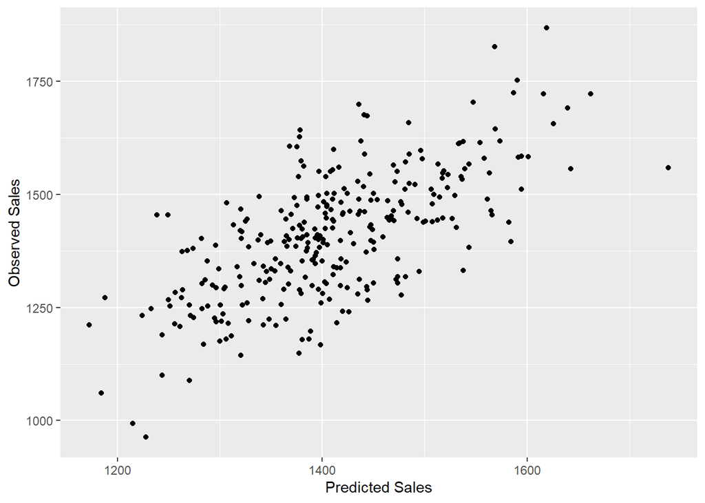

```r
ggplot(ice_cream_data, aes(x=PredictedSales, y=IceCreamsales))+geom_point()+labs(x="Predicted Sales", y="Observed Sales")
```

#There is a positive relationship between predicted sales and observed sales of Ice Cream.

# Random effects by Location

```r
ranef(ice_cream_model)
```

```
## $Location
##   (Intercept)
## 1           0
## 2           0
## 3           0
##
## with conditional variances for "Location"
```